# European Soccer (2008-2018)

```python
# Dealing 2

player_rank.isna().sum
# Lets replace Null values with some higher value so that the graph will be complete and the highest value represent null

player_rank = player_rank.replace(np.NaN,20)
player_rank
```

| player_name | rank1 | rank2 | rank3 | rank4 | rank5 |
| --- | --- | --- | --- | --- | --- |
| Neymar | 1.0 | 20.0 | 20.0 | 20.0 | 1.0 |
| Manuel Neuer | 2.0 | 3.0 | 3.0 | 20.0 | 2.0 |
| Arjen Robben | 3.0 | 4.0 | 4.0 | 20.0 | 3.0 |
| Eden Hazard | 4.0 | 20.0 | 20.0 | 20.0 | 4.0 |
| Mesut Oezil | 5.0 | 20.0 | 20.0 | 20.0 | 5.0 |
| Robert Lewandowski | 6.0 | 20.0 | 20.0 | 20.0 | 20.0 |
| Sergio Aguero | 7.0 | 20.0 | 20.0 | 20.0 | 20.0 |
| James Rodriguez | 8.0 | 20.0 | 20.0 | 20.0 | 20.0 |
| David De Gea | 9.0 | 20.0 | 20.0 | 20.0 | 20.0 |
| Toni Kroos | 10.0 | 20.0 | 20.0 | 20.0 | 20.0 |
| Lionel Messi | 20.0 | 1.0 | 1.0 | 1.0 | 20.0 |
| Cristiano Ronaldo | 20.0 | 2.0 | 2.0 | 2.0 | 20.0 |
| Luis Suarez | 20.0 | 5.0 | 20.0 | 20.0 | 20.0 |
| Zlatan Ibrahimovic | 20.0 | 20.0 | 5.0 | 20.0 | 20.0 |
| Radamel Falcao | 20.0 | 20.0 | 20.0 | 3.0 | 20.0 |
| Franck Ribery | 20.0 | 20.0 | 20.0 | 4.0 | 20.0 |
| Andres Iniesta | 20.0 | 20.0 | 20.0 | 5.0 | 20.0 |

```python
# To pick the top 10 players, we will come up with a sum of rank column.
# We will add all their ranks and filter out the top 10 players based on the sum
# Then we will drop the column as it wont be used to plot

player_rank['sum_rank'] = player_rank[['rank1', 'rank2','rank3', 'rank4', 'rank5']].sum(axis=1)

#Picking the top 10
player_rank =  player_rank.sort_values('sum_rank').head(10)

player_rank
```

| player_name | rank1 | rank2 | rank3 | rank4 | rank5 | sum_rank |
| --- | --- | --- | --- | --- | --- | --- |
| Manuel Neuer | 2.0 | 3.0 | 3.0 | 20.0 | 2.0 | 30.0 |
| Arjen Robben | 3.0 | 4.0 | 4.0 | 20.0 | 3.0 | 34.0 |
| Lionel Messi | 20.0 | 1.0 | 1.0 | 1.0 | 20.0 | 43.0 |
| Cristiano Ronaldo | 20.0 | 2.0 | 2.0 | 2.0 | 20.0 | 46.0 |
| Neymar | 1.0 | 20.0 | 20.0 | 20.0 | 1.0 | 62.0 |
| Eden Hazard | 4.0 | 20.0 | 20.0 | 20.0 | 4.0 | 68.0 |
| Mesut Oezil | 5.0 | 20.0 | 20.0 | 20.0 | 5.0 | 70.0 |
| Radamel Falcao | 20.0 | 20.0 | 20.0 | 3.0 | 20.0 | 83.0 |
| Franck Ribery | 20.0 | 20.0 | 20.0 | 4.0 | 20.0 | 84.0 |
| Zlatan Ibrahimovic | 20.0 | 20.0 | 5.0 | 20.0 | 20.0 | 85.0 |

```python
#Once the sum is calculated and the players are sorted accordingly, we can drop the column. It is no use for us further
player_rank  = player_rank.drop('sum_rank',axis=1)
player_rank
```

| player_name | rank1 | rank2 | rank3 | rank4 | rank5 |
| --- | --- | --- | --- | --- | --- |
| Manuel Neuer | 2.0 | 3.0 | 3.0 | 20.0 | 2.0 |
| Arjen Robben | 3.0 | 4.0 | 4.0 | 20.0 | 3.0 |
| Lionel Messi | 20.0 | 1.0 | 1.0 | 1.0 | 20.0 |
| Cristiano Ronaldo | 20.0 | 2.0 | 2.0 | 2.0 | 20.0 |
| Neymar | 1.0 | 20.0 | 20.0 | 20.0 | 1.0 |
| Eden Hazard | 4.0 | 20.0 | 20.0 | 20.0 | 4.0 |
| Mesut Oezil | 5.0 | 20.0 | 20.0 | 20.0 | 5.0 |
| Radamel Falcao | 20.0 | 20.0 | 20.0 | 3.0 | 20.0 |
| Franck Ribery | 20.0 | 20.0 | 20.0 | 4.0 | 20.0 |
| Zlatan Ibrahimovic | 20.0 | 20.0 | 5.0 | 20.0 | 20.0 |

```python
# The columns names in the rank dataframe is simply 'rank'. IF we plot graph for this, it will be indicated in the graph as legend.
# This will not make for a great plot and not much of meaning can be derived from that plot.

# Instead, We need the players to be indicated and the graph to depict their rank over the years.
# We have player names as the index and ranks as the columns.
# We would like the data to be the other way around. Hence we transpose the matrix
df_plot = player_rank.T
df_plot
```

| player_name | Manuel Neuer | Arjen Robben | Lionel Messi | Cristiano Ronaldo | Neymar | Eden Hazard | Mesut Oezil | Radamel Falcao | Franck Ribery | Zlatan Ibrahimovic |
| --- | --- | --- | --- | --- | --- | --- | --- | --- | --- | --- |
| rank1 | 2.0 | 3.0 | 20.0 | 20.0 | 1.0 | 4.0 | 5.0 | 20.0 | 20.0 | 20.0 |
| rank2 | 3.0 | 4.0 | 1.0 | 2.0 | 20.0 | 20.0 | 20.0 | 20.0 | 20.0 | 20.0 |
| rank3 | 3.0 | 4.0 | 1.0 | 2.0 | 20.0 | 20.0 | 20.0 | 20.0 | 20.0 | 5.0 |
| rank4 | 20.0 | 20.0 | 1.0 | 2.0 | 20.0 | 20.0 | 20.0 | 3.0 | 4.0 | 20.0 |
| rank5 | 2.0 | 3.0 | 20.0 | 20.0 | 1.0 | 4.0 | 5.0 | 20.0 | 20.0 | 20.0 |

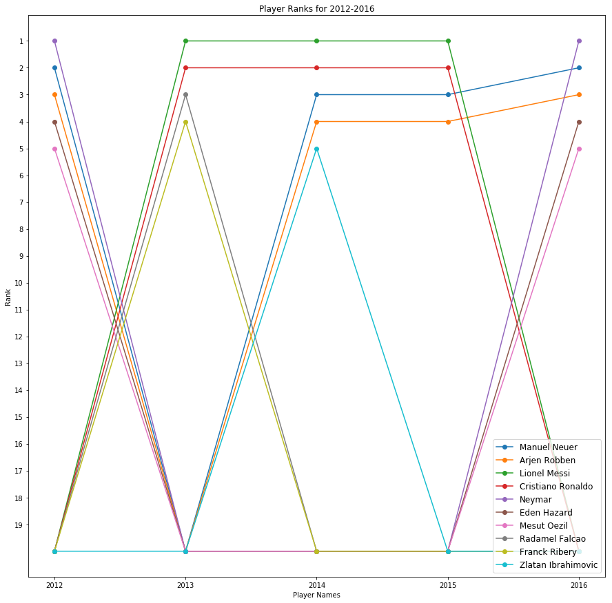

```python
# Now lets plot the values of the above dataframe

df_plot.plot(kind='line',figsize=(15,15), marker='o')
plt.gca().invert_yaxis() #inverting y axis
plt.gca().invert_xaxis() #inverting y axis
plt.yticks(range(1,20))  #Range of y values
plt.ylabel("Rank")

ind = np.arange(5)
plt.xticks(ind, ("2016","2015","2014","2013","2012"))
plt.xlabel("Player Names")
plt.legend(loc = "lower right" , prop = {"size" : 12})
plt.title("Player Ranks for 2012-2016")
plt.show();
```

## Limitations in Data

> To be frank, there are a couple of limitations to this dataset, which may/may not cause some problems if we happpen to analyse the data set further.

> You will notice that some players are missing from the lineup (NULL values). There are also NULL values in the ranks. This made is difficult to plot the ranks of players. We had to work around it by raplacing null with some random value. This will not be pretty in the long run.

## Conclusions

#### From the detailed analysis, below are the conclusions drawn in regards to our research questions.

> Lionel Messi is the best player of the year 2010.

> Spain Liga BBVA is the league with highest number of home goals.

```python
from subprocess import call
call(['python', '-m', 'nbconvert', 'Investigate_a_Dataset.ipynb'])
```